# Population Genetics Activity

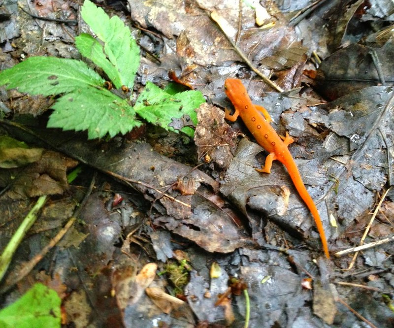

## Overview

This activity will focus on the using genetic data.

## The Data

```r
library( tidyverse )
library( gstudio )
data( arapat )
```

The data for this activity is included in the `gstudio` library and represents a set of nuclear co-dominant loci (named *LTRS, WNT, EN, EF, ZMP, AML, ATPS, MP20*) assayed for 363 individuals and partitioned into 3 partitions.

```r
summary( arapat )
```

```
      Species      Cluster      Population        ID         Latitude
 Cape     : 75   CBP-C :150   32     : 19   101_10A:  1   Min.   :23.08
 Mainland : 36   NBP-C : 84   75     : 11   101_1A :  1   1st Qu.:24.59
 Peninsula:252   SBP-C : 18   Const  : 11   101_2A :  1   Median :26.25
                 SCBP-A: 75   12     : 10   101_3A :  1   Mean   :26.25
                 SON-B : 36   153    : 10   101_4A :  1   3rd Qu.:27.53
                              157    : 10   101_5A :  1   Max.   :29.33
                              (Other):292   (Other):357
   Longitude          LTRS          WNT            EN           EF
 Min.   :-114.3   01:01 :147   03:03  :108   01:01  :225   01:01 :219
 1st Qu.:-113.0   01:02 : 86   01:01  : 82   01:02  : 52   01:02 : 52
 Median :-111.5   02:02 :130   01:03  : 77   02:02  : 38   02:02 : 90
 Mean   :-111.7                02:02  : 62   03:03  : 22   NA's  :  2
 3rd Qu.:-110.5                03:04  :  8   01:03  :  7
 Max.   :-109.1                (Other): 15   (Other): 16
                               NA's   : 11   NA's   :  3
     ZMP           AML           ATPS          MP20
 01:01 : 46   08:08  : 51   05:05  :155   05:07  : 64
 01:02 : 51   07:07  : 42   03:03  : 69   07:07  : 53
 02:02 :233   07:08  : 42   09:09  : 66   18:18  : 52
 NA's  : 33   04:04  : 41   02:02  : 30   05:05  : 48
              07:09  : 22   07:09  : 14   05:06  : 22
              (Other):142   08:08  :  9   (Other):119
              NA's   : 23   (Other): 20   NA's   :  5
```

1. Create all potential genotypes *de novo* for a locus with 3 alleles.
2. At the ATPS locus, there are several genotypes that are observed only once in the entire data set. What are these genotypes and which populations are they found in?
3. Look at the composition of *Populations* in the *arapat* data set with particular attention to *Species*. This species is a parasite on a limited habit resource. Ecologically, what is happening here?
4. One way to see if ther is any indication that *Peninsula* and *Cape* species are interbreeding would be to look to see if there are alleles that are unique to one of the groups and not in the other. A stronger inference would be gained if those *private* alleles were within individuals who are in the same physical location. For the sites where both *Peninsula* and *Cape* taxonomic groups co-exist is there any evidence of alleles in one species but not in the other?